# Part 3

Alexis Kwan

# 1 Exploratory Analysis

## 1.1 Sales Ratios

The sales ratio is one of the standard ways of analyzing the accuracy of property assessments, where the sales ratio is defined as the assessed value of a property divided by the sale price.

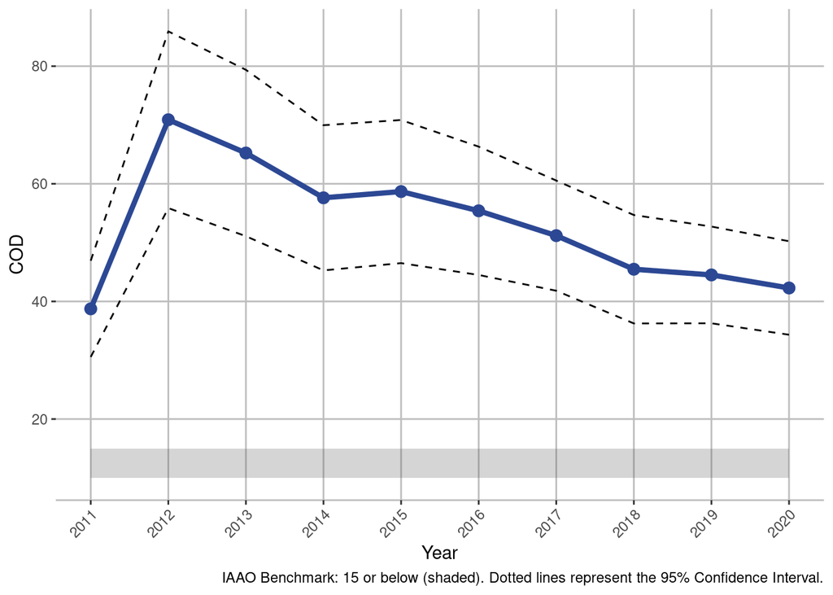

By Michigan state law the limit for sales ratios in Detroit is 50% of market value, which means that if a property is assessed over 50% it is over assessed, and if under 50%, under assessed.

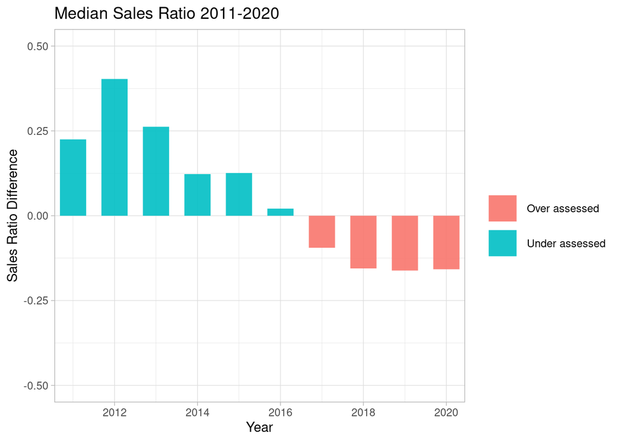

## 1.2 Sales and Foreclosures

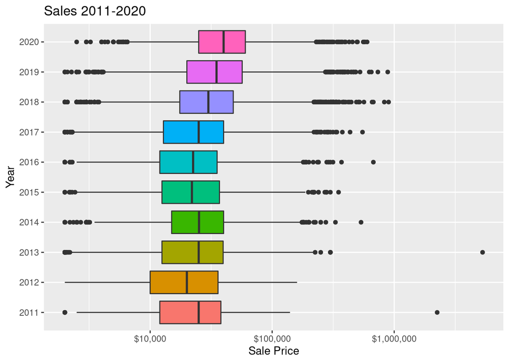

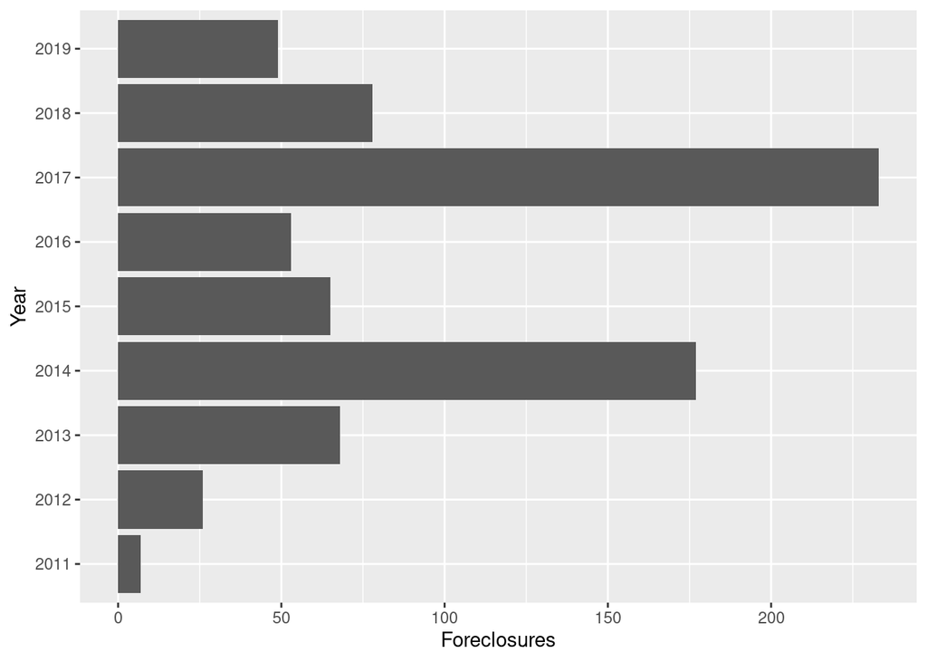

# 2 Modeling Property Value and Assessment

## 2.1 Overassessment of 2016 Properties

First, we want to find a way to identify if a home is likely to be overassessed in a given year. We will analyze homes and assessments from 2016. Use 2016 sales and assessments with the parcels property characteristics (note that we only know if a home was overassessed if it sold). Create a classification metric of overassessment based on properties which sold and use this as your dependent variable.

[output not shown]

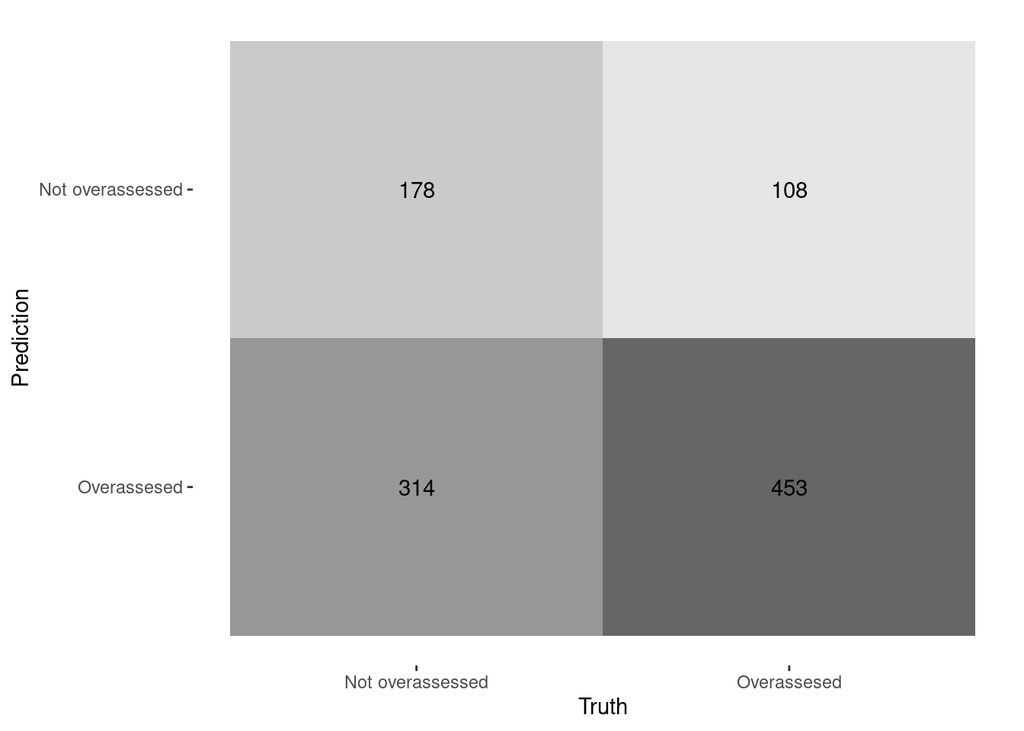

| METRIC | ESTIMATOR | ESTIMATE |
| --- | --- | --- |
| accuracy | binary | 0.5992403 |
| kap | binary | 0.1737491 |
| sens | binary | 0.3617886 |
| spec | binary | 0.8074866 |
| ppv | binary | 0.6223776 |
| npv | binary | 0.5906128 |
| mcc | binary | 0.1898789 |
| j_index | binary | 0.1692752 |
| bal_accuracy | binary | 0.5846376 |
| detection_prevalence | binary | 0.2716049 |

[output cut: 3 more lines]

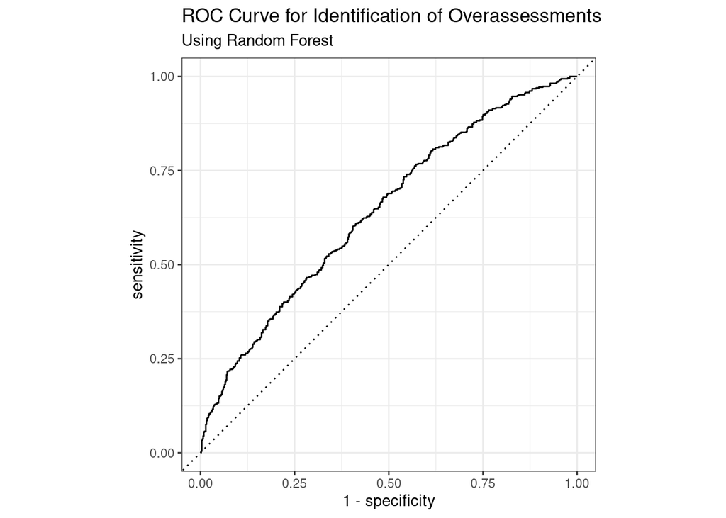

The ROC curve above specifies how well our classification model would do if we adjusted the threshold for determining whether something is overassessed or not. There is a fairly even trade off between getting true positives and false positives as we increase the treshold. We will use Bayesian optimization next to attempt to improve the model.

[output not shown]

[output not shown]

[output not shown]

[output not shown]

[output not shown]

[output not shown]

[output not shown]

[output not shown]

[output not shown]

[output not shown]

[output not shown]

[output not shown]

[output not shown]

[output not shown]

[output not shown]

[output not shown]

[output not shown]

[output not shown]

[output not shown]

[output not shown]

[output not shown]

[output not shown]

[output not shown]

[output not shown]

[output not shown]

[output not shown]

[output not shown]

[output not shown]

[output not shown]

[output not shown]

[output not shown]

[output not shown]

[output not shown]

[output not shown]

[output not shown]

[output not shown]

[output not shown]

[output not shown]

[output not shown]

[output not shown]

[output not shown]

[output not shown]

[output not shown]

[output not shown]

[output not shown]

[output not shown]

[output not shown]

[output not shown]

[output not shown]

[output not shown]

[output not shown]

[output not shown]

[output not shown]

[output not shown]

[output not shown]

[output not shown]

[output not shown]

[output not shown]

[output not shown]

[output not shown]

[output not shown]

[output not shown]

[output not shown]

[output not shown]

[output not shown]

[output not shown]

[output not shown]

[output not shown]

[output not shown]

[output not shown]

[output not shown]

| trees | min_n | .config |
| --- | --- | --- |
| 1797 | 30 | Preprocessor1_Model5 |

The best parameters for random forest modeling are shown above.

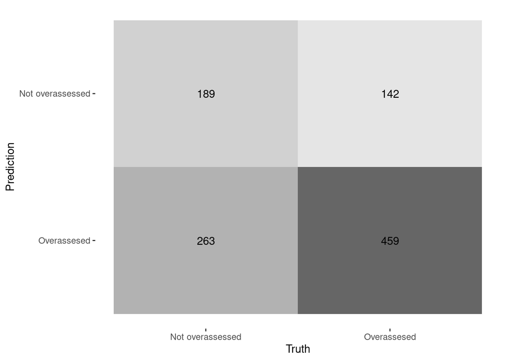

However we see that even with the tuning the model did not perform much better.

## 2.2 2019 Assessments of Property Value

```
## i 1 of 3 tuning:     base_linear_reg
```

```
## ✓ 1 of 3 tuning:     base_linear_reg (8.1s)
```

```
## i 2 of 3 tuning:     base_random_forest
```

```
## i Creating pre-processing data to finalize unknown parameter: mtry
```

```
## ✓ 2 of 3 tuning:     base_random_forest (8m 3.1s)
```

```
## i 3 of 3 tuning:     base_nearest_neighbor
```

```
## ✓ 3 of 3 tuning:     base_nearest_neighbor (2m 26.9s)
```

```
## # A tibble: 1 × 3
##       penalty mixture .config
##         <dbl>   <dbl> <fct>
## 1 0.000000130   0.745 Preprocessor1_Model4
```

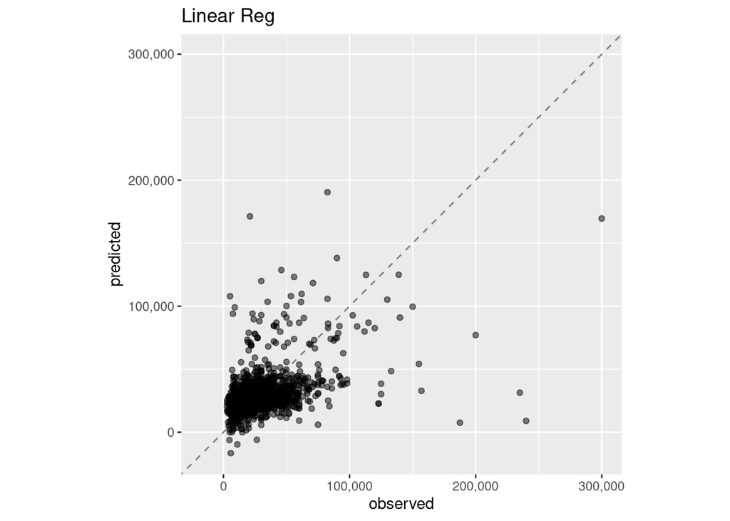

```
## # A tibble: 1 × 3
##    mtry min_n .config
##   <int> <int> <fct>
## 1   158     5 Preprocessor1_Model4
```

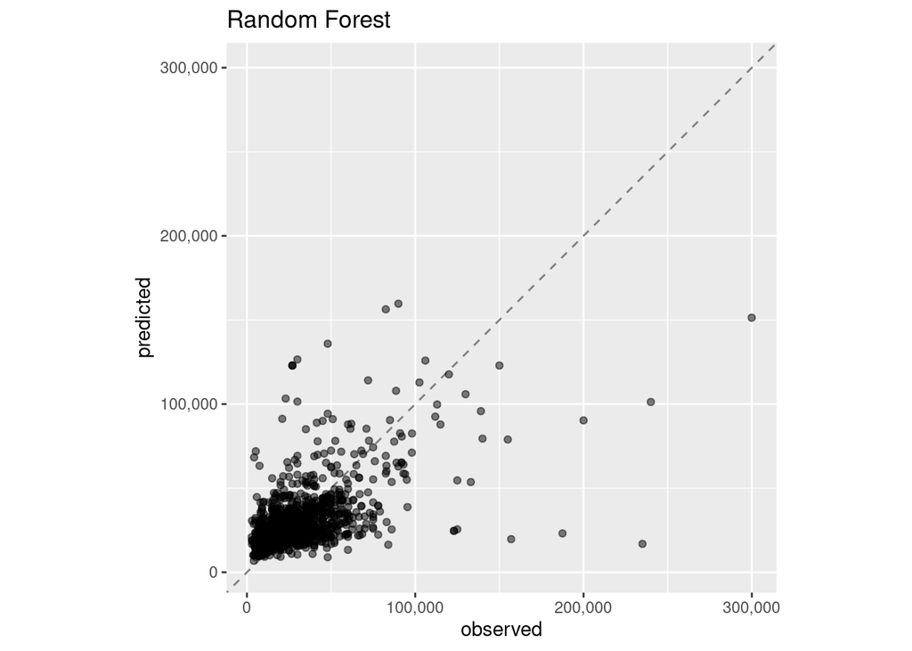

```
## # A tibble: 1 × 3
##   neighbors weight_func .config
##       <int> <chr>       <fct>
## 1         8 rank        Preprocessor1_Model3
```

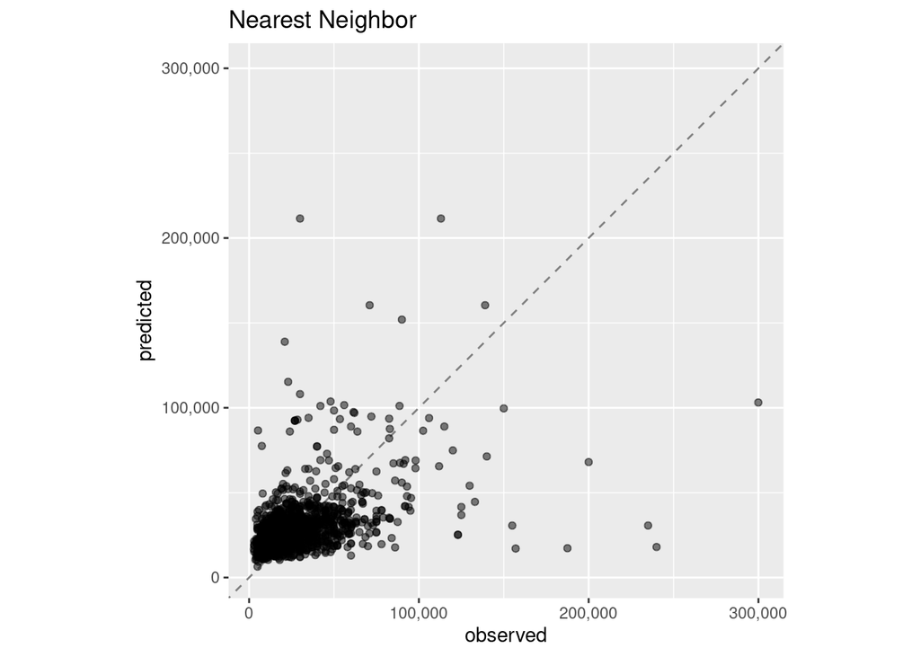

# 3 Conclusion

A combination of variables representing geographic location, neighborhood, square footage and zoing were used to predict valuations. A combination of variables representing similar abstractions, along with property improvements were used for the overassessments. I tried to use variables that mirrored physical aspects of the properties as much as possible, as well as social aspects.

I would implment these models in actual use cases unless more data were accrued or use in combination with a lot of manual assessment, especially of the properties with falsely predicted values. This includes both overassessment and valuation.